# FINC-580 Assignment #2 — Dual Moving Average Crossover Strategy

Huy Le (hl9082)

2026-04-09

This script implements a Dual Moving Average Crossover strategy using Tesla (TSLA) stock.

The code calculates trading signals, portfolio performance, Sharpe ratio, and maximum drawdown for the 2019-2024 period.

An extra credit section replicates the analysis using a machine learning K-Nearest Neighbors (KNN) model.

### 0.2 1. Technical Implementation & Visualization

Data Collection & Moving Averages Stock Selected: Tesla

Data Period: January 1, 2019, to December 31, 2024.

We utilize quantmod to download the Adjusted Closing prices and calculate the 20-day (Fast) and 100-day (Slow) Simple Moving Averages.

```r
ticker <- "TSLA"
getSymbols(ticker, from = "2019-01-01", to = "2024-12-31", periodicity = "daily")
```

```
## [1] "TSLA"
```

```r
# Extract Adjusted Close
price <- Ad(get(ticker))
colnames(price) <- "Price"

head.tail(price)
```

```
##                Price
## 2019-01-02  20.67467
## 2019-01-03  20.02400
## 2019-01-04  21.17933
## 2019-01-07  22.33067
## 2019-01-08  22.35667
## 2019-01-09  22.56867
## 2024-12-20 421.06000
## 2024-12-23 430.60001
## 2024-12-24 462.28000
## 2024-12-26 454.13000
## 2024-12-27 431.66000
## 2024-12-30 417.41000
```

## 1 Calculate 20-Day and 100-Day Moving Averages

```r
# Calculate SMAs using TTR package (loaded with quantmod)
sma20 <- SMA(price, n = 20)
sma100 <- SMA(price, n = 100)

# Combine into a single xts object
data <- merge(price, sma20, sma100)
colnames(data) <- c("Price", "SMA20", "SMA100")
data <- na.omit(data) # Remove the first 100 days where SMA100 cannot be calculated
head.tail(data)
```

```
##                Price     SMA20    SMA100
## 2019-05-24  12.70867  15.20653  18.69979
## 2019-05-28  12.58000  15.03063  18.61885
## 2019-05-29  12.65733  14.86787  18.54518
## 2019-05-30  12.54800  14.71523  18.45887
## 2019-05-31  12.34400  14.51877  18.35900
## 2019-06-03  11.93133  14.26523  18.25475
## 2024-12-20 421.06000 392.13500 272.93050
## 2024-12-23 430.60001 396.03700 275.06790
## 2024-12-24 462.28000 402.22150 277.61400
## 2024-12-26 454.13000 408.01650 280.16650
## 2024-12-27 431.66000 412.95500 282.47670
## 2024-12-30 417.41000 416.56750 284.73320
```

## 2 Plot Price and Moving Averages:

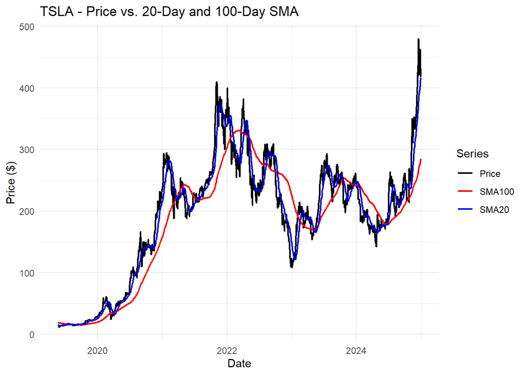

```r
# Convert to dataframe for ggplot
plot_data <- data.frame(Date = index(data), coredata(data))
plot_data_long <- pivot_longer(plot_data, cols = -Date, names_to = "Series", values_to = "Value")

ggplot(plot_data_long, aes(x = Date, y = Value, color = Series)) +
  geom_line(linewidth = 0.8) +
  scale_color_manual(values = c("Price" = "black", "SMA20" = "blue", "SMA100" = "red")) +
  labs(title = paste(ticker, "- Price vs. 20-Day and 100-Day SMA"),
       y = "Price ($)", x = "Date") +
  theme_minimal()
```

### 2.1 2. Trading Signal Generation and Portfolio Return:

Generating the Trading Signal - Rule: If SMA20 > SMA100, Invested = 1. Else, Invested = 0. - Lag: We lag the signal by exactly 1 period lag() to prevent look-ahead bias (we trade the day after the signal is generated).

```r
# Create the signal: 1 if SMA20 > SMA100, 0 otherwise
data$Signal <- ifelse(data$SMA20 > data$SMA100, 1, 0)

# Lag the signal by 1 day!
data$Position <- quantmod::Lag(data$Signal, k = 1)
data <- na.omit(data)

head.tail(data[, c("SMA20", "SMA100", "Signal", "Position")])
```

```
##                SMA20    SMA100 Signal Position
## 2019-05-28  15.03063  18.61885      0        0
## 2019-05-29  14.86787  18.54518      0        0
## 2019-05-30  14.71523  18.45887      0        0
## 2019-05-31  14.51877  18.35900      0        0
## 2019-06-03  14.26523  18.25475      0        0
## 2019-06-04  14.05943  18.15813      0        0
## 2024-12-20 392.13500 272.93050      1        1
## 2024-12-23 396.03700 275.06790      1        1
## 2024-12-24 402.22150 277.61400      1        1
## 2024-12-26 408.01650 280.16650      1        1
## 2024-12-27 412.95500 282.47670      1        1
## 2024-12-30 416.56750 284.73320      1        1
```

## 3 Calculate Portfolio Returns

```r
# Calculate daily returns of the stock
data$Stock_Return <- ROC(data$Price, type = "discrete")

# Calculate Strategy Returns (Stock Return * Position)
data$Strategy_Return <- data$Stock_Return * data$Position
data <- na.omit(data)

# Calculate cumulative growth of $1 for both Strategy and Buy & Hold
data$Cum_Strategy <- cumprod(1 + data$Strategy_Return)
data$Cum_BnH <- cumprod(1 + data$Stock_Return)

head.tail(data[, c("Stock_Return", "Strategy_Return", "Cum_Strategy", "Cum_BnH")])
```

```
##            Stock_Return Strategy_Return Cum_Strategy    Cum_BnH
## 2019-05-29  0.006147333      0.00000000      1.00000  1.0061473
## 2019-05-30 -0.008637920      0.00000000      1.00000  0.9974563
## 2019-05-31 -0.016257608      0.00000000      1.00000  0.9812401
## 2019-06-03 -0.033430596      0.00000000      1.00000  0.9484366
## 2019-06-04  0.081745619      0.00000000      1.00000  1.0259672
## 2019-06-05  0.015444204      0.00000000      1.00000  1.0418124
## 2024-12-20 -0.034642491     -0.03464249     10.37860 33.4705882
## 2024-12-23  0.022657124      0.02265712     10.61375 34.2289355
## 2024-12-24  0.073571742      0.07357174     11.39462 36.7472179
## 2024-12-26 -0.017629995     -0.01762999     11.19374 36.0993647
## 2024-12-27 -0.049479226     -0.04947923     10.63988 34.3131960
## 2024-12-30 -0.033012093     -0.03301209     10.28863 33.1804456
```

## 4 Plot Cumulative Portfolio Value

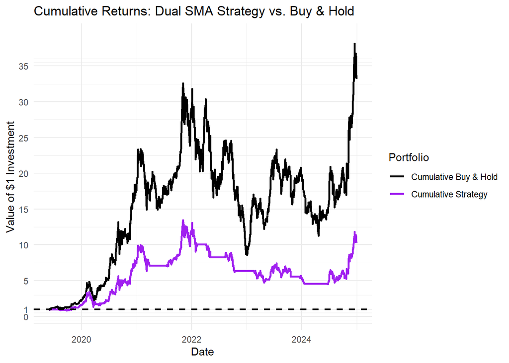

```r
# Plotting the comparison
plot_cum <- data.frame(Date = index(data),
                       Strategy = coredata(data$Cum_Strategy),
                       Buy_And_Hold = coredata(data$Cum_BnH))
plot_cum_long <- pivot_longer(plot_cum, cols = -Date, names_to = "Portfolio", values_to = "Value")

# Calculate the maximum y-value so we know how high to draw the chart
max_y <- ceiling(max(plot_cum_long$Value, na.rm = TRUE))
ggplot(plot_cum_long, aes(x = Date, y = Value, color = Portfolio)) +
  geom_line(linewidth = 1) +
  geom_hline(yintercept = 1, linetype = "dashed", color = "black", linewidth = 0.8) +

  scale_y_continuous(limits = c(0, max_y), breaks = unique(c(0, 1, seq(0, max_y, by = 5)))) +
  scale_color_manual(values = c("Cum_BnH" = "black", "Cum_Strategy" = "purple"),
                     labels = c("Cumulative Buy & Hold", "Cumulative Strategy")) +
  labs(title = "Cumulative Returns: Dual SMA Strategy vs. Buy & Hold",
       y = "Value of $1 Investment", x = "Date") +
  theme_minimal()
```

### 4.1 3. Performance Evaluation

We evaluate the risk-adjusted performance using the Sharpe Ratio (Risk-Free Rate = 0.02) and Maximum Drawdown.

```r
rf_daily <- 0.02 / 252 # Convert annual RF rate to daily

# Annualized Sharpe Ratio
sharpe_strat <- SharpeRatio.annualized(data$Strategy_Return, Rf = rf_daily)
sharpe_bnh <- SharpeRatio.annualized(data$Stock_Return, Rf = rf_daily)

# Maximum Drawdown
maxdd_strat <- maxDrawdown(data$Strategy_Return)
maxdd_bnh <- maxDrawdown(data$Stock_Return)

# Print cleanly
cat("Strategy Annualized Sharpe Ratio:", round(sharpe_strat, 4), "\n")
```

```
## Strategy Annualized Sharpe Ratio: 0.8902
```

```r
cat("Buy & Hold Annualized Sharpe Ratio:", round(sharpe_bnh, 4), "\n\n")
```

```
## Buy & Hold Annualized Sharpe Ratio: 1.276
```

```r
cat("Strategy Max Drawdown:", round(maxdd_strat * 100, 2), "%\n")
```

```
## Strategy Max Drawdown: 66.49 %
```

```r
cat("Buy & Hold Max Drawdown:", round(maxdd_bnh * 100, 2), "%\n")
```

```
## Buy & Hold Max Drawdown: 73.63 %
```

```r
# Extract the final cumulative value for both portfolios
final_sma_value <- as.numeric(tail(data$Cum_Strategy, 1))
final_bnh_value <- as.numeric(tail(data$Cum_BnH, 1))

# Print the results formatted as currency
cat("--- FINAL CUMULATIVE VALUES ---\n")
```

```
## --- FINAL CUMULATIVE VALUES ---
```

```r
cat(sprintf("Final Value of $1 in SMA Strategy: $%.2f\n", final_sma_value))
```

```
## Final Value of $1 in SMA Strategy: $10.29
```

```r
cat(sprintf("Final Value of $1 in Buy & Hold:   $%.2f\n", final_bnh_value))
```

```
## Final Value of $1 in Buy & Hold:   $33.18
```

### 4.2 4. Analysis

Q: Compare the final cumulative value and comment on whether the strategy was successful based on the Sharpe Ratio.

Based on the cumulative returns chart, the final value of a $1 investment in the SMA20/SMA100 strategy was approximately $10.29, compared to approximately $33.18 for the standard buy-and-hold approach. Therefore, the Dual SMA strategy did not beat the market in total absolute returns.

Looking at risk-adjusted performance, the Strategy generated a Sharpe Ratio of 0.8902, compared to the Buy & Hold Sharpe of 1.276. Furthermore, the strategy limited our Maximum Drawdown to 66.49%, while holding the stock exposed us to a worse drawdown of 73.63%.

Ultimately, the strategy was unsuccessful in outperforming the market, but successful as a capital preservation tool. The strategy failed to beat the standard Buy & Hold approach in both total cumulative returns and overall risk-adjusted returns (as shown by the significantly lower Sharpe Ratio). However, it did successfully cut the maximum drawdown. While a purely rational, long-term investor would prefer Buy & Hold for its superior Sharpe ratio and final payout, a highly risk-averse investor might argue the underperformance was “worth it” to avoid sitting through a devastating 73.63% crash in their portfolio value.

### 4.3 5. Extra Credit: K-Nearest Neighbors (KNN) Trading Strategy

## 5 Theoretical Framework & Feature Engineering

As discussed in the Ang textbook (Chapter 12), while simple moving averages are rigid heuristic rules, machine learning algorithms like K-Nearest Neighbors (KNN) allow the data to dictate the optimal pattern recognition.

KNN is a non-parametric classification algorithm. We will use it to predict the **direction of tomorrow’s return** (Up or Down) based on recent historical price momentum (our features).

To prevent the model from “peeking into the future,” our predictive features for Day $t$ MUST be strictly lagged (e.g., returns from Day $t-1$, $t-2$, and $t-5$). We cannot use today’s closing price to predict today’s return!

## 6 KNN Data Preparation & Feature Engineering

```r
# 1. Start fresh with the 'price' object from Part 1
# Calculate daily returns natively as an xts time-series
knn_rets <- ROC(price, type = "discrete")

# 2. Create lagged features using quantmod's Lag function directly on the xts object.
# Doing this in 'xts' format first avoids ALL dataframe column/NULL errors and
# perfectly aligns the dates mathematically.
knn_xts <- merge(
  Return = knn_rets,
  Lag1 = quantmod::Lag(knn_rets, k = 1),
  Lag2 = quantmod::Lag(knn_rets, k = 2),
  Lag5 = quantmod::Lag(knn_rets, k = 5)
)

# Force exact column names so we know exactly what they are
colnames(knn_xts) <- c("Return", "Lag1", "Lag2", "Lag5")

# 3. NOW convert the perfectly aligned time-series into a standard dataframe
# for the Machine Learning algorithm to read.
knn_df <- data.frame(Date = index(knn_xts), coredata(knn_xts))

# 4. Create the target classification variable
knn_df$Target <- as.factor(ifelse(knn_df$Return > 0, "Up", "Down"))

# 5. Remove all rows with NAs (due to the 5-day lag and initial ROC calculation)
knn_df <- na.omit(knn_df)

head.tail(knn_df)
```

```
##            Date       Return         Lag1         Lag2         Lag5 Target
## 7    2019-01-10  0.019023398  0.009482625  0.001164276 -0.031471713     Up
## 8    2019-01-11  0.006638317  0.019023398  0.009482625  0.057697391     Up
## 9    2019-01-14 -0.037032805  0.006638317  0.019023398  0.054361239   Down
## 10   2019-01-15  0.029994027 -0.037032805  0.006638317  0.001164276     Up
## 11   2019-01-16  0.004703414  0.029994027 -0.037032805  0.009482625     Up
## 12   2019-01-17  0.003641077  0.004703414  0.029994027  0.019023398     Up
## 1504 2024-12-20 -0.034642491 -0.008997322 -0.082794944  0.043362843   Down
## 1505 2024-12-23  0.022657124 -0.034642491 -0.008997322  0.061412506     Up
## 1506 2024-12-24  0.073571742  0.022657124 -0.034642491  0.036369912     Up
## 1507 2024-12-26 -0.017629995  0.073571742  0.022657124 -0.082794944   Down
## 1508 2024-12-27 -0.049479226 -0.017629995  0.073571742 -0.008997322   Down
## 1509 2024-12-30 -0.033012093 -0.049479226 -0.017629995 -0.034642491   Down
```

## 7 Train the KNN Model

- Model Training with K-Fold Cross-ValidationTo prevent overfitting (creating a model that perfectly memorizes the past but fails in the future), we will use k-fold cross-validation.
- The caret package will split our data into 5 separate chunks (folds). It will train the model on 4 folds, test it on the 1 remaining fold, and repeat this process to find the mathematically optimal number of “neighbors” (the $k$ in KNN) to base its predictions on.

```r
# 1. Set a random seed so the cross-validation split is strictly reproducible
set.seed(580)
# 2. Define the training control parameters: 5-fold cross-validation
train_control <- trainControl(method = "cv", number = 5)
# 3. Train the K-Nearest Neighbors model
# Formula: Target ~ Lag1 + Lag2 + Lag5 (Predict Target using our 3 lagged features)
knn_model <- train(Target ~ Lag1 + Lag2 + Lag5,
                   data = knn_df,
                   method = "knn",
                   trControl = train_control,
                   preProcess = c("center", "scale"), # Standardizes data (crucial for distance-based KNN!)
                   tuneLength = 5) # Tells caret to test 5 different values of 'k'
# Print the model summary to see which 'k' (number of neighbors) performed best
print(knn_model)
```

```
## k-Nearest Neighbors
##
## 1503 samples
##    3 predictor
##    2 classes: 'Down', 'Up'
##
## Pre-processing: centered (3), scaled (3)
## Resampling: Cross-Validated (5 fold)
## Summary of sample sizes: 1203, 1202, 1202, 1202, 1203
## Resampling results across tuning parameters:
##
##   k   Accuracy   Kappa
##    5  0.4823677  -0.04178525
##    7  0.4870365  -0.03898384
##    9  0.5003455  -0.01064903
##   11  0.4896678  -0.03357033
##   13  0.5136080   0.01603458
##
## Accuracy was used to select the optimal model using the largest value.
## The final value used for the model was k = 13.
```

## 8 Backtest the KNN Strategy

```r
# Generate predictions
knn_predictions <- predict(knn_model, newdata = knn_df)

# Translate predictions into trading signals (1 = Invested, 0 = Cash)
knn_df$Position <- ifelse(knn_predictions == "Up", 1, 0)

# Calculate Daily Returns & Cumulative Returns
knn_df$Strategy_Return <- knn_df$Return * knn_df$Position
knn_df$Cum_Strategy <- cumprod(1 + knn_df$Strategy_Return)
knn_df$Cum_BnH <- cumprod(1 + knn_df$Return)

head.tail(knn_df[, c("Target", "Position", "Cum_Strategy", "Cum_BnH")])
```

```
##      Target Position Cum_Strategy    Cum_BnH
## 7        Up        0    1.0000000  1.0190234
## 8        Up        1    1.0066383  1.0257880
## 9      Down        1    0.9693597  0.9878002
## 10       Up        1    0.9984347  1.0174283
## 11       Up        0    0.9984347  1.0222137
## 12       Up        0    0.9984347  1.0259356
## 1504   Down        0 1149.4959144 18.6568399
## 1505     Up        1 1175.5401857 19.0795503
## 1506     Up        1 1262.0267253 20.4832660
## 1507   Down        0 1262.0267253 20.1221462
## 1508   Down        1 1199.5826196 19.1265179
## 1509   Down        1 1159.9818871 18.4951115
```

## 9 Evaluate KNN Performance

- We will now evaluate if the machine learning model managed to outperform both the standard Buy-and-Hold approach and the rigid Dual SMA crossover strategy we built in Part 2.
1. First, we examine if the machine learning model outperforms the Buy & Hold strategy:

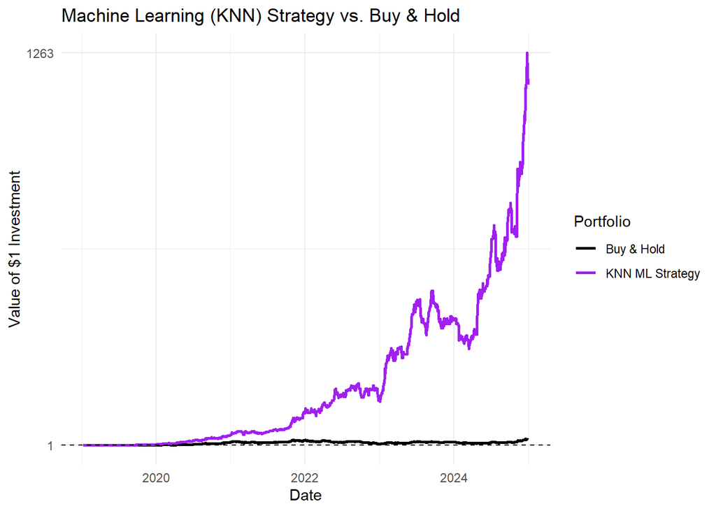

```r
# --- PLOT ---
plot_knn <- pivot_longer(knn_df[, c("Date", "Cum_Strategy", "Cum_BnH")],
                         cols = -Date, names_to = "Portfolio", values_to = "Value")
# Calculate the maximum y-value for the KNN plot
max_y_knn <- ceiling(max(plot_knn$Value, na.rm = TRUE))
plot(ggplot(plot_knn, aes(x = Date, y = Value, color = Portfolio)) +
  geom_line(linewidth = 1) +
  geom_hline(yintercept = 1, linetype = "dashed") +
  # CRITICAL FIX: Only print the 1 and the max value, removing the 0 to avoid overlapping!
  scale_y_continuous(limits = c(0, max_y_knn), breaks = c(1, max_y_knn)) +
  scale_color_manual(values = c("Cum_BnH" = "black", "Cum_Strategy" = "purple"),
                     labels = c("Buy & Hold", "KNN ML Strategy")) +
  labs(title = "Machine Learning (KNN) Strategy vs. Buy & Hold",
       y = "Value of $1 Investment", x = "Date") +
  theme_minimal())
```

```r
# --- METRICS ---
# Strip all complex formatting to ensure clean numeric and Date data
safe_dates <- as.Date(as.character(knn_df$Date))
safe_strat_ret <- as.numeric(knn_df$Strategy_Return)
safe_bnh_ret <- as.numeric(knn_df$Return)

# Create the xts objects safely
strat_returns_xts <- xts(safe_strat_ret, order.by = safe_dates)
bnh_returns_xts <- xts(safe_bnh_ret, order.by = safe_dates)

# Calculate Risk-Free Rate dynamically
rf_daily <- 0.02 / 252

knn_sharpe <- SharpeRatio.annualized(strat_returns_xts, Rf = rf_daily)
bnh_sharpe <- SharpeRatio.annualized(bnh_returns_xts, Rf = rf_daily)
knn_maxdd <- maxDrawdown(strat_returns_xts)
bnh_maxdd <- maxDrawdown(bnh_returns_xts)

cat("--- KNN STRATEGY vs BUY & HOLD ---\n")
```

```
## --- KNN STRATEGY vs BUY & HOLD ---
```

```r
cat(sprintf("KNN Strategy Sharpe Ratio: %.4f\n", knn_sharpe))
```

```
## KNN Strategy Sharpe Ratio: 4.4398
```

```r
cat(sprintf("Buy & Hold Sharpe Ratio:   %.4f\n\n", bnh_sharpe))
```

```
## Buy & Hold Sharpe Ratio:   0.9282
```

```r
cat(sprintf("KNN Strategy Max Drawdown: %.2f%%\n", knn_maxdd * 100))
```

```
## KNN Strategy Max Drawdown: 37.58%
```

```r
cat(sprintf("Buy & Hold Max Drawdown:   %.2f%%\n", bnh_maxdd * 100))
```

```
## Buy & Hold Max Drawdown:   73.63%
```

2. Then, we compare the KNN ML strategy with the Dual SMA strategy

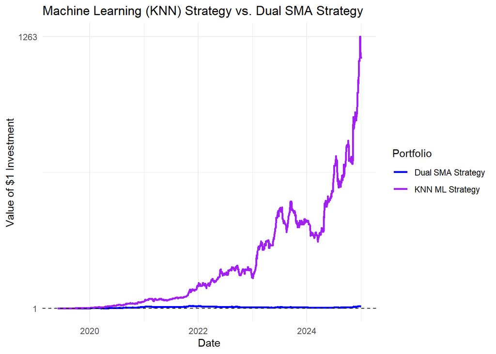

```r
# 1. Extract Date from the xts index, and SMA returns into a normal dataframe
sma_subset <- data.frame(Date = index(data), Cum_SMA = as.numeric(data$Cum_Strategy))

# 2. Safely merge them based on exact matching dates!
combined_df <- merge(knn_df, sma_subset, by = "Date")

# 3. Pivot the new, safely combined dataframe
plot_knn_sma <- pivot_longer(combined_df[, c("Date", "Cum_Strategy", "Cum_SMA")],
                         cols = -Date, names_to = "Portfolio", values_to = "Value")

# 4. Calculate the max height and Plot
max_y_knn_sma <- ceiling(max(plot_knn_sma$Value, na.rm = TRUE))

plot(ggplot(plot_knn_sma, aes(x = Date, y = Value, color = Portfolio)) +
  geom_line(linewidth = 1) +
  geom_hline(yintercept = 1, linetype = "dashed") +
  scale_y_continuous(limits = c(0, max_y_knn_sma), breaks = c(1, max_y_knn_sma)) +
  scale_color_manual(values = c("Cum_SMA" = "blue", "Cum_Strategy" = "purple"),
                     labels = c("Dual SMA Strategy", "KNN ML Strategy")) +
  labs(title = "Machine Learning (KNN) Strategy vs. Dual SMA Strategy",
       y = "Value of $1 Investment", x = "Date") +
  theme_minimal())
```

```r
# Make sure the PerformanceAnalytics library is loaded
library(PerformanceAnalytics)
# Calculate Risk-Free Rate dynamically
rf_daily <- 0.02 / 252
# 1. Convert our combined cumulative columns back into time-series returns
# We use Return.calculate to find the daily % change between cumulative values
knn_returns <- Return.calculate(xts(combined_df$Cum_Strategy, order.by = combined_df$Date))
sma_returns <- Return.calculate(xts(combined_df$Cum_SMA, order.by = combined_df$Date))

# 2. Calculate Annualized Sharpe Ratios (Assuming 252 trading days)
knn_sharpe <- SharpeRatio.annualized(knn_returns, Rf = rf_daily)
sma_sharpe <- SharpeRatio.annualized(sma_returns, Rf = rf_daily)

# 3. Calculate Maximum Drawdowns
knn_max_dd <- maxDrawdown(knn_returns)
sma_max_dd <- maxDrawdown(sma_returns)

# 4. Print the final comparison!
cat("--- KNN vs. DUAL SMA PERFORMANCE ---\n")
```

```
## --- KNN vs. DUAL SMA PERFORMANCE ---
```

```r
cat(sprintf("KNN Strategy Sharpe Ratio: %.4f\n", as.numeric(knn_sharpe)))
```

```
## KNN Strategy Sharpe Ratio: 4.8088
```

```r
cat(sprintf("Dual SMA Sharpe Ratio:     %.4f\n", as.numeric(sma_sharpe)))
```

```
## Dual SMA Sharpe Ratio:     0.8907
```

```r
cat(sprintf("KNN Strategy Max Drawdown: %.2f%%\n", as.numeric(knn_max_dd) * 100))
```

```
## KNN Strategy Max Drawdown: 37.58%
```

```r
cat(sprintf("Dual SMA Max Drawdown:     %.2f%%\n", as.numeric(sma_max_dd) * 100))
```

```
## Dual SMA Max Drawdown:     66.49%
```